# CHAPTER C2

安定な断面を持つ柱の強度

## C2.1 柱の破壊方法。柱の方程式。

第A18章では、柱の弾性および非弾性不安定性の理論が提示された。端部ピン支持条件に対する第A18章からの方程式は以下の通りである。

弾性一次破壊に対して、

$$F_c = \frac{\pi^2 E}{(L/\rho)^2}$$
—(1)

非弾性一次破壊に対して、

$$F_c = \frac{\pi^2 E_t}{(L/\rho)^2}$$
—(2)

ここで、 $F_c$ = 破壊時の圧縮単位応力 = $P/A$ 応力 $E$ = ヤング率 $E_t$ = 接線係数 $L$ = 柱の長さ $\rho$ = 断面の回転半径

Fig. C2.1は、 $F_c$ 対 $L/\rho$ の典型的なプロットを示している。柱の寸法が Fig. C2.1 の範囲CDで破壊するようなものである場合、一次破壊は弾性不安定性によるものであり、式(1)が成り立つ。この $L/\rho$ 値の範囲は、技術者によって長柱範囲としばしば呼ばれる。

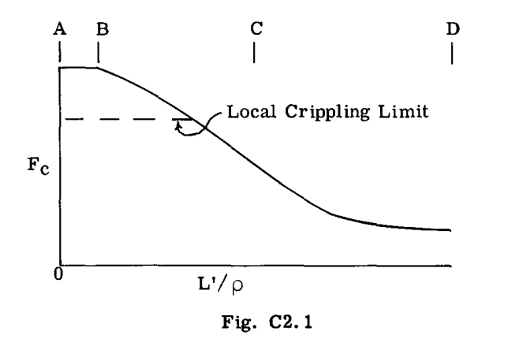

Fig. C2.1

範囲BCは、柱全体の非弾性不安定性によって破壊が生じる $L/\rho$ 値の範囲を表し、式(2)が適用される。この範囲BCは、しばしば短柱範囲と呼ばれる。

Fig. C2.1の範囲ABは、 $L/\rho$ の値が20から25未満の範囲であり、柱の塑性圧壊による破壊が生じる範囲を表す。言い換えれば、柱は端部荷重の下で座屈したりたわんだりするには短すぎるが、高い応力の下で押しつぶされる。この柱の応力範囲は、通常、ブロック圧縮強度と呼ばれる。

しかし、柱は、その面内における柱断面の歪みによる局所的な座屈またはクリップリング（局所座屈破壊）によって破壊することがある。Fig. C2.1の水平破線は、一次柱強度が局所的な弱さによって制限される条件を表している。この線は、局所的な弱さの値に応じて上下に移動する。破壊が局所的な弱さによるものである場合の柱強度の決定は、別の章で扱われる。

## C2.2 柱の端部拘束。固定度係数。柱の有効長さ。

柱の強度は、回転に対する端部支持の拘束、および柱端部間の任意の中間ラテラル支持によって影響を受ける。記号 $c$ は一般に端部固定度係数を示すために使用され、機械的にピンまたはボールアンドソケットの端部支持フィッティングによって生成できる回転に対する端部拘束がゼロの場合は $c = 1.0$ である。したがって、端部拘束効果を含めると、式(1)および(2)は次のように書くことができる。

$$F_c = \frac{c \pi^2 E}{(L/\rho)^2} , \quad F_c = \frac{c \pi^2 E_t}{(L/\rho)^2}$$
—(3)

$L'$ = 荷重下のたわんだ柱の変曲点間の長さに等しい柱の有効長さ、とする。

すると、

$$L' = L / \sqrt{c}$$
—(4)

したがって、式(3)は次のように書くことができる。

$$F_c = \frac{\pi^2 E}{(L'/\rho)^2} , \quad F_c = \frac{\pi^2 E_t}{(L'/\rho)^2}$$
—(5)

$P$ = 破壊荷重または臨界荷重とすると、 $\rho = \sqrt{I/A}$ および $P = F_c A$ であることを認識することにより、式(5)は式(6)として書くことができる。

$$P = \frac{\pi^2 E I}{(L')^2} , \quad P = \frac{\pi^2 E_t I}{(L')^2}$$
—(6)

Fig. C2.2は、様々な端部および中間ラテラル支持条件に対して、荷重 $P$ の下でのたわんだ柱の曲線を示している。有効長さ $L'$ および端部固定度係数もリストされている。

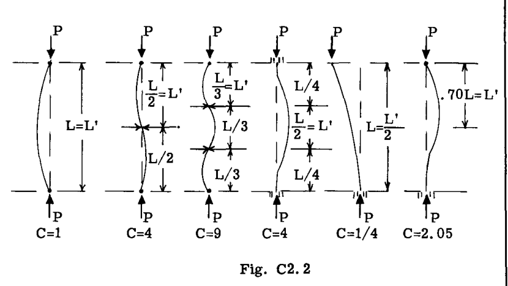

Fig. C2.2

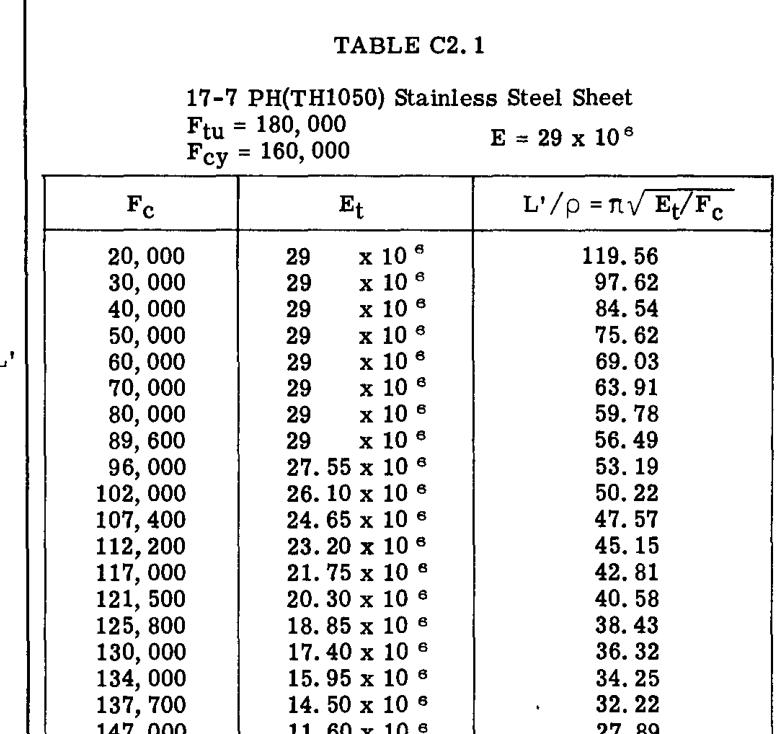

TABLE C2.1

## C2.3 各種材料の設計柱曲線

日常の設計目的には、許容破壊柱応力 $F_c$ 対有効細長比 $L'/\rho$ の柱曲線を持つことが便利である。式(5)において、まず $F_c$ の値を仮定し、次にこの応力に対応する接線係数 $E_t$ を求め、その後、項 $L'/\rho$ について解く。Table C2.1は、室温における17-7 PH (TH1050) ステンレス鋼板の計算を示している。その結果は Fig. C2.7 にプロットされ、柱強度曲線が与えられる。特定の曝露時間における異なる高温下での材料に対しても同様のデータが計算され、その結果も Fig. C2.7 にプロットされている。Figs. C2.3 から C2.15 は、様々な温度条件下の他の材料に対する柱曲線を示している。これらの曲線の使用は、この章の後半の例題でなされる。水平破線は圧縮耐力（降伏応力）である。これらのカットオフ線を超える値は、試験によって実証される必要がある。

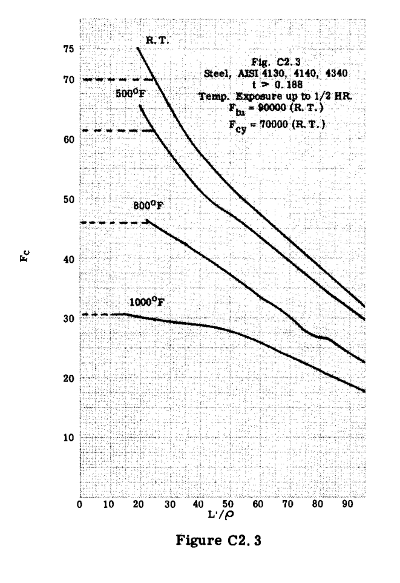

Figure C2.3

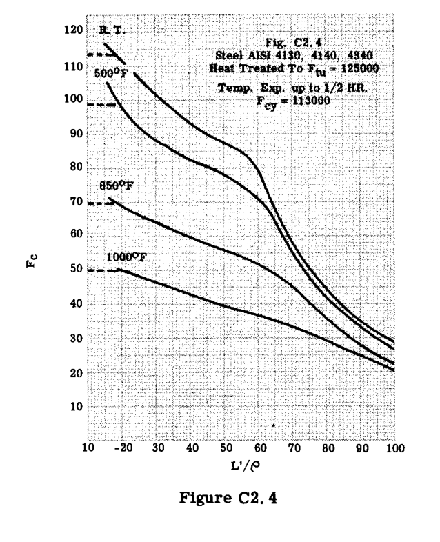

Figure C2.4

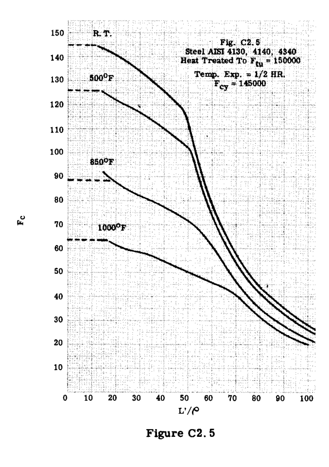

Figure C2.5

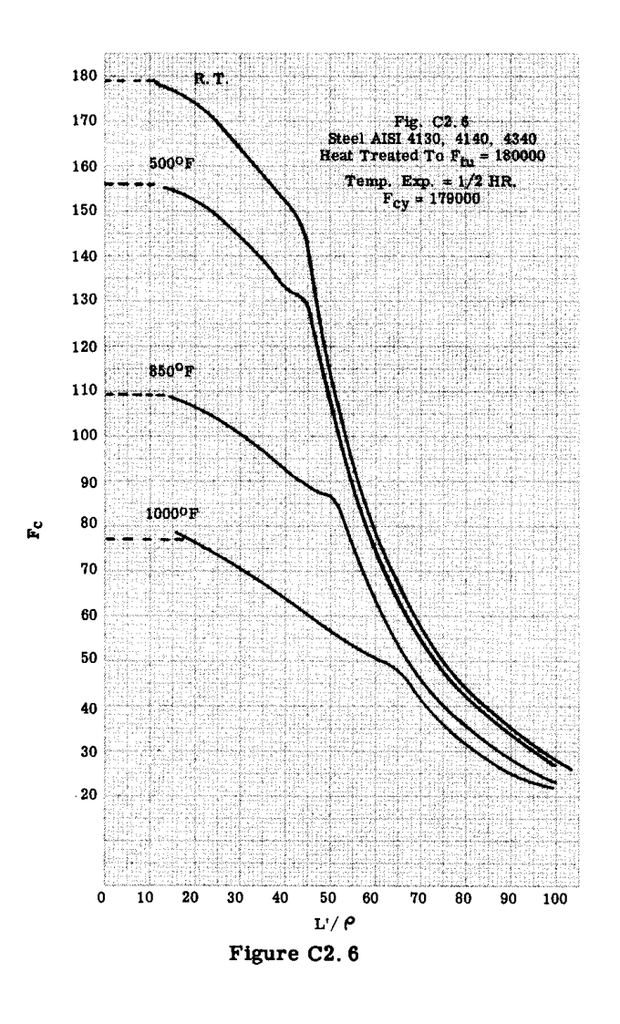

Figure C2.6

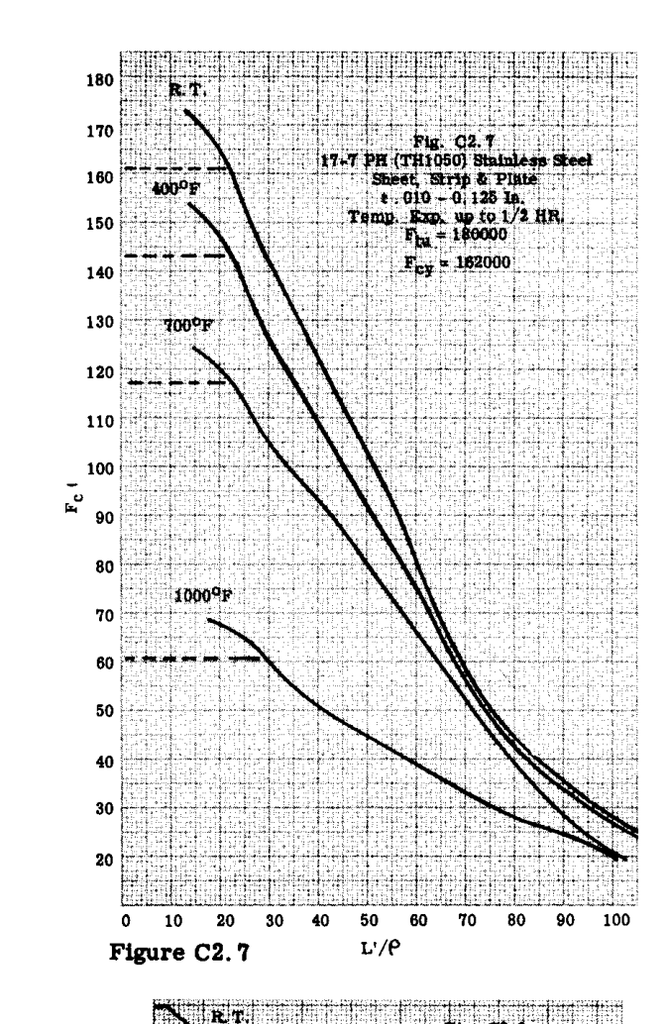

Figure C2.7

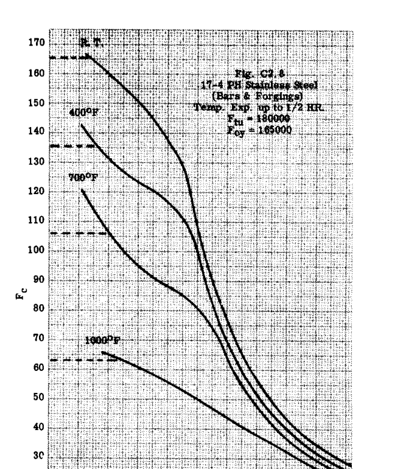

Figure C2.8

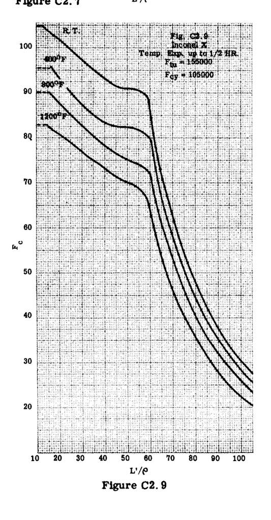

Figure C2.9

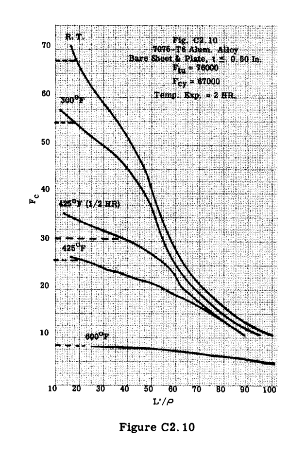

Figure C2.10

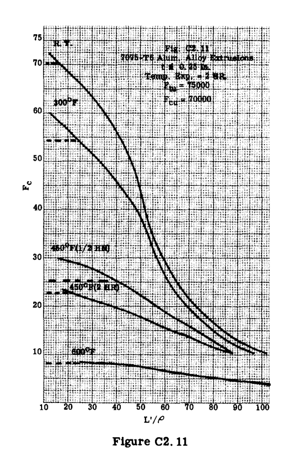

Figure C2.11

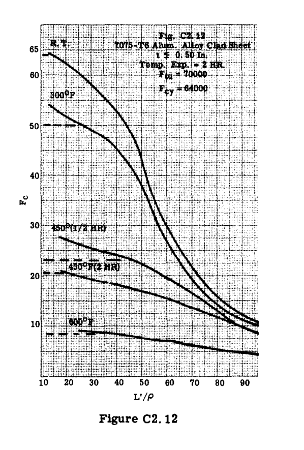

Figure C2.12

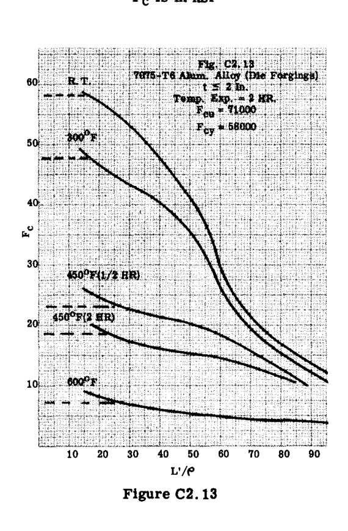

Figure C2.13

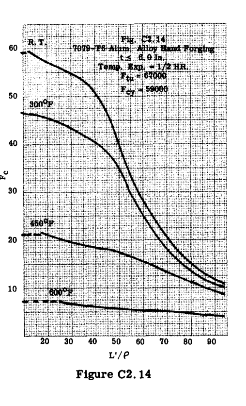

Figure C2.14

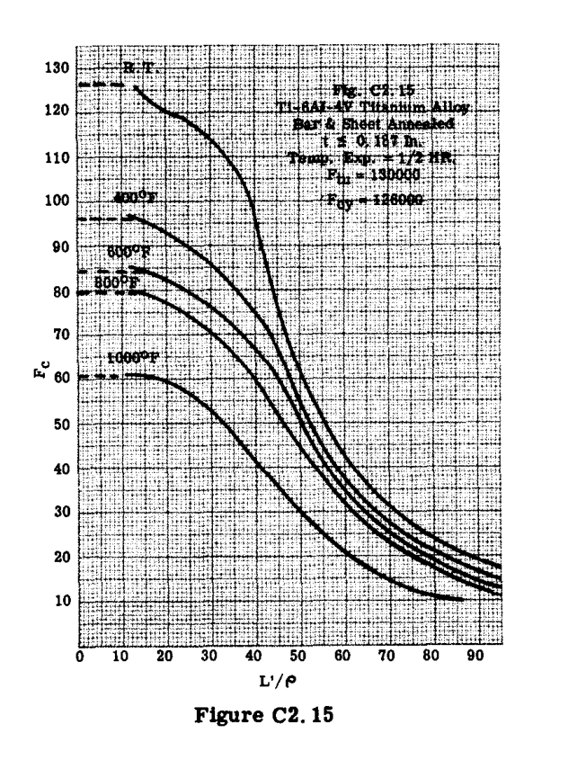

Figure C2.15

## C2.4 Ramberg-Osgood式による接線係数 $E_t$

$E_t$ に対する基本的なRamberg-Osgoodの関係式は以下の通りである（参考文献1参照）：

$$\frac{E_t}{E} = \frac{1}{1 + \frac{3}{7} n \left( \frac{F}{F_{0.7}} \right)^{n-1}}$$
—(7)

ここで、 $E_t$ = 弾性接線係数 $E$ = 弾性係数（縦弾性係数）

その他の用語の定義については、第B1章のArticle B1.12を参照されたい。

この方程式は Fig. C2.16 にプロットされている。与えられた材料に対して、 $n$ 、 $F_{0.7}$ 、および $E$ が既知でなければならない。次に $F$ の値を仮定すると、Fig. C2.16 から対応する $E_t/E$ の値を見つけることができる。 $E$ 、 $F_{0.7}$ 、および $n$ の値については、第B1章のTable B1.1を参照されたい。

## C2.5 無次元化された柱曲線

CozzoneとMelconによって、非常に有用な無次元化された柱曲線が導出されている（参考文献3参照）。

オイラーの柱方程式は $F = \pi^2 E_t / (L'/\rho)^2$ であり、これは次のように書くことができる。

$$\frac{E_t}{F} = \frac{(L'/\rho)^2}{\pi^2}$$

したがって、問題は無次元関係から $E_t/F$ の式を得ることに帰着する。これを行うには、式(7)の両辺に $F_{0.7}/F$ を掛け、 $B^2$ に等しくする。

$$\left( \frac{E_t}{E} \right) \left( \frac{F_{0.7}}{F} \right) = \frac{1}{\frac{F}{F_{0.7}} + \frac{3}{7} n \left( \frac{F}{F_{0.7}} \right)^n} = B^2$$
—(8)

Fig. C2.17は、参考文献3から引用したこの方程式のプロットを示しており、様々な $n$ の値に対する $F/F_{0.7}$ 対 $B$ を示している。

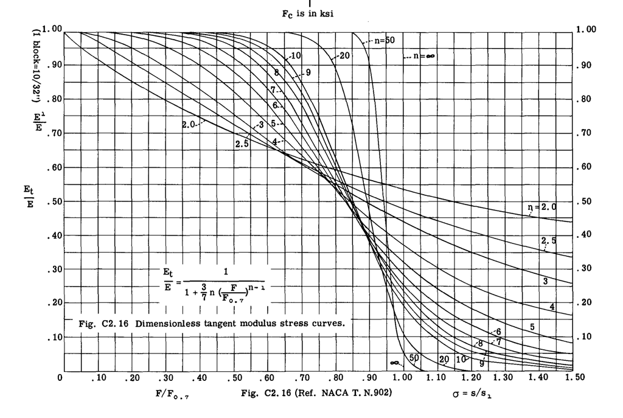

Fig. C2.16

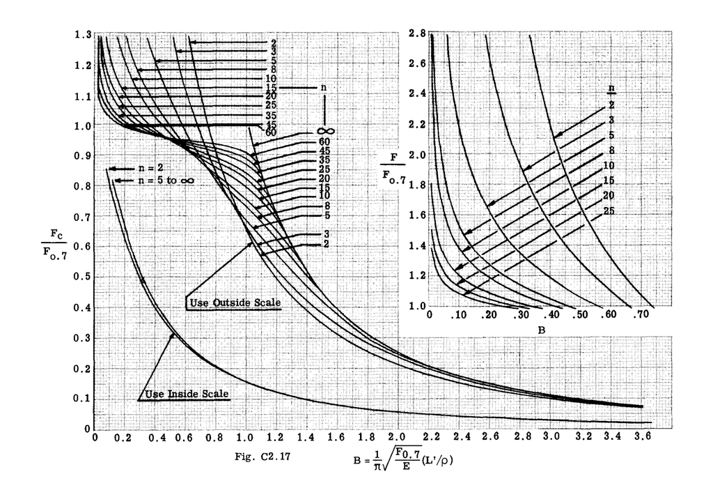

Fig. C2.17

式(8)に $F = \pi^2 E_t / (L'/\rho)^2$ の値を代入すると、

$$\left( \frac{E_t}{\pi^2 E_t / (L'/\rho)^2} \right) \left( \frac{F_{0.7}}{E} \right) = B^2$$

または

$$B = \frac{1}{\pi} \sqrt{\frac{F_{0.7}}{E}} \left( \frac{L'}{\rho} \right)$$
—(9)

Fig. C2.17の曲線の使用は、後の例題の解答において説明される。

## C2.6 変化する断面または慣性モーメントを持つ柱の強度

組立柱または鍛造柱の重量を節約するために、部材をテーパーにするか、不均一な断面で作成する。このような柱の極限強度を見つけるには、通常、試行錯誤法を使用する必要がある。柱のたわみを考慮した一般的な解決方法は、均一な断面を持つ長柱の場合について説明される。

Fig. C2.18は、極限荷重または臨界荷重 $P$ を支持しているときの、たわんだ中立平衡状態にあるピン支持柱を示している。たわんだ柱の形状が正弦波曲線関係に従い、中間点でのたわみが1に等しいと仮定する（Fig. C2.18参照）。

たわんだ柱の曲線の式は、

$$y = \sin \frac{\pi x}{L}$$

である。 $P$ が端部荷重である場合、任意の点における曲げモーメントは、

$$M = P y = P \sin \frac{\pi x}{L}$$

である。

よく知られた「モーメント面積」の定理（第A7章、Art. A7.14参照）により、弾性曲線上の点(A)の接線から別の点(B)へのたわみは、(A)と(B)の間の $M/EI$ 図の面積の(A)に関する一次モーメントに等しい。

したがって、Fig. C2.18において、端部(0)の中間点(C)における接線からのたわみは、仮定条件において1に等しく、これは(0)と(C)の間の $M/EI$ 図の面積の(0)に関する一次モーメントにも等しい（Fig. C2.19）。

0から任意の距離 $x$ における $M/EI$ 図の縦座標の値は、

$$\frac{P}{EI} \sin \frac{\pi x}{L}$$

である。曲線の下の全面積は、

$$\text{area} = \frac{P}{EI} \int_0^L \sin \frac{\pi x}{L} dx = \frac{P}{EI} \left[ -\frac{L}{\pi} \cos \frac{\pi x}{L} \right]_0^L$$

$$= -\frac{P L}{\pi EI} (\cos \pi - \cos 0) = -\frac{P L}{\pi EI} (-1 - 1) = \frac{2 P L}{\pi EI}$$

したがって、面積 $= \frac{2PL}{\pi EI}$ であり、半分の面積 $= \frac{PL}{\pi EI}$ である。

半分の面積の重心は、

$$A \bar{x} = \int x dA$$

$$\left( \frac{P L}{\pi EI} \right) \bar{x} = \frac{P}{EI} \int_0^{L/2} x \sin \frac{\pi x}{L} dx$$

$$\frac{L}{\pi} \bar{x} = \int_0^{L/2} x \sin \frac{\pi x}{L} dx$$

この簡単な式を積分して $x$ について解くと、以下が得られる。

$$\bar{x} = L/\pi$$

0とCの間の $M/EI$ 図の、点(0)に関するモーメントをとると：

$$y_0 = 1 = \frac{PL}{\pi EI} \cdot \frac{L}{\pi} = \frac{PL^2}{\pi^2 EI}$$

したがって、

$$P = \frac{\pi^2 EI}{L^2}$$

これはオイラーの方程式であり、したがって、想定された正弦波曲線が柱のたわんだ弾性曲線に対して適切なものであったことがわかる。

図の半分の面積は、

$$\frac{1}{2} \left( \frac{2}{3} L \times \frac{P}{EI} \right) = \frac{P L}{3 EI}$$

0とCの間の面積の、0に関するモーメントをとると：

$$y_0 = 1 = \frac{PL}{3 EI} \cdot \frac{5}{16} L = \frac{5PL^2}{48EI}$$

したがって、

$$P = \frac{9.6 EI}{L^2}$$

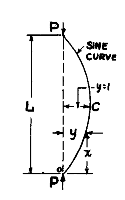

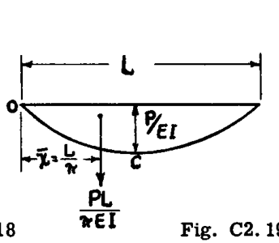